# Anexo: Modelos de Regresión Ordinal con Ingresos Re-escalados

¿Quién justifica qué? El rol del sentido de injusticia en las justificaciones de violencia en contexto de protesta

Martin Venegas Márquez

29/10/2022

# Introducción

El presente documento corresponde al análisis multivariado de la tésis titulada “¿Quién justifica qué? El rol del sentido de injusticia en las justificaciones de violencia en contexto de protesta”.

## Modelos Ordinales con Ingresos Re-Escalados

### Justificación estudiantes lancen piedras

Modelo SJ

Modelo Grupos Desaventajados

Modelo Ideologia

Modelo Trato Justo

Modelo Interacciones

Predictores

β

β

β

β

β

Nunca se justifica|Pocas veces se justifica

1.40 ***

1.23

-1.11

-2.21 **

0.01

Pocas veces se justifica|Algunas veces se justifica

2.14 ***

1.99 **

-0.32

-1.39

0.86

Algunas veces se justifica|Muchas veces se justifica

3.29 ***

3.15 ***

0.87

-0.15

2.12

Muchas veces se justifica|Siempre se justifica

4.23 ***

4.10 ***

1.84 *

0.85

3.14 *

J Gerente

0.22 **

0.23 **

0.23 **

0.22 *

1.86 **

J’ Obrero

0.28

0.30

0.13

0.07

0.09

J Entrevistado

-0.12

-0.08

-0.00

0.09

0.08

Ingresos Entrevistado

-0.03

-0.04

-0.02

0.00

Sexo: Mujer

-0.49 **

-0.54 **

-0.51 **

0.01

Satisfaccion Ingresos:  
Ingresos Entrevistado:  
Satisfecho

-0.40

-0.26

-0.26

2.07

Satisfaccion Ingresos:  
Ingresos Entrevistado: Ni  
satisfecho ni  
insatisfecho

0.02

0.09

0.07

2.20

Satisfaccion Ingresos:  
Ingresos Entrevistado:  
Insatisfecho

-0.18

-0.11

-0.17

1.78

Satisfaccion Ingresos:  
Ingresos Entrevistado:  
Totalmente insatisfecho

0.28

0.42

0.19

2.60 *

Nivel Educacional CINE  
11: Primaria y secundaria  
baja

0.18

0.16

0.14

0.08

Nivel Educacional CINE  
11: Secundaria alta

0.20

0.06

0.22

0.15

Nivel Educacional CINE  
11: Terciaria ciclo corto

0.14

-0.13

-0.00

-0.03

Nivel Educacional CINE  
11: Terciaria y Postgrado

0.39

-0.09

0.10

0.01

Pertenencia a Pueblo  
Indigena: Otro pueblo

0.58

0.59

0.64

0.72

Pertenencia a Pueblo  
Indigena: Mapuche

0.37

0.45

0.40

0.33

SDO Indice

-0.45

-0.20

-0.22

RWA Indice

-2.75 ***

-2.91 ***

-3.10 ***

Trato Respetuoso Salud:  
Casi nunca

-0.28

-0.20

Trato Respetuoso Salud: A  
veces

-0.16

-0.10

Trato Respetuoso Salud:  
Casi siempre

0.20

0.25

Trato Respetuoso Salud:  
Siempre

0.27

0.30

Trato Respetuoso  
Carabineros: Casi nunca

-0.90 **

-0.91 **

Trato Respetuoso  
Carabineros: A veces

-1.23 ***

-1.27 ***

Trato Respetuoso  
Carabineros: Casi siempre

-1.77 ***

-1.82 ***

Trato Respetuoso  
Carabineros: Siempre

-1.60 ***

-1.61 ***

sj_ceo_rec:sexo_factorMujer

-0.42 *

sj_ceo_rec:ingreso_satisfact_factorSatisfecho

-1.68 **

sj_ceo_rec:ingreso_satisfact_factorNi satisfecho ni insatisfecho

-1.46 *

sj_ceo_rec:ingreso_satisfact_factorInsatisfecho

-1.33 *

sj_ceo_rec:ingreso_satisfact_factorTotalmente insatisfecho

-1.69 **

Observations

711

711

711

711

711

R<sup>2</sup> Nagelkerke

0.019

0.047

0.103

0.157

0.176

- p<0.05 ** p<0.01 *** p<0.001

### Justificación carabineros repriman marchas

Modelo SJ

Modelo Grupos Desaventajados

Modelo Ideologia

Modelo Trato Justo

Modelo Interacciones

Predictores

β

β

β

β

β

Nunca se justifica|Pocas veces se justifica

0.48 *

-1.01

2.85 **

3.68 ***

3.90 ***

Pocas veces se justifica|Algunas veces se justifica

1.30 ***

-0.16

3.74 ***

4.58 ***

4.80 ***

Algunas veces se justifica|Muchas veces se justifica

2.51 ***

1.07

5.02 ***

5.87 ***

6.10 ***

Muchas veces se justifica|Siempre se justifica

4.42 ***

2.98 ***

6.96 ***

7.81 ***

8.05 ***

J Gerente

-0.07

-0.08

-0.10

-0.11

-0.10

J’ Obrero

-0.89 ***

-0.74 **

-0.45

-0.42

-0.04

J Entrevistado

0.39

0.23

0.22

0.11

0.08

Ingresos Entrevistado

0.01

0.01

0.00

0.01

Sexo: Mujer

-0.31

-0.28

-0.31

-0.25

Satisfaccion Ingresos:  
Ingresos Entrevistado:  
Satisfecho

-0.29

-0.43

-0.54

-0.56

Satisfaccion Ingresos:  
Ingresos Entrevistado: Ni  
satisfecho ni  
insatisfecho

-0.34

-0.49

-0.60

-0.62

Satisfaccion Ingresos:  
Ingresos Entrevistado:  
Insatisfecho

-0.58

-0.67

-0.77

-0.78

Satisfaccion Ingresos:  
Ingresos Entrevistado:  
Totalmente insatisfecho

-0.57

-0.74

-0.78

-0.85

Nivel Educacional CINE  
11: Primaria y secundaria  
baja

-1.14 *

-1.24 **

-1.18 *

-1.68 *

Nivel Educacional CINE  
11: Secundaria alta

-1.13 ***

-1.08 ***

-1.18 ***

-0.76

Nivel Educacional CINE  
11: Terciaria ciclo corto

-1.12 **

-0.93 **

-1.03 **

-0.49

Nivel Educacional CINE  
11: Terciaria y Postgrado

-1.15 ***

-0.70

-0.87 *

-0.43

Pertenencia a Pueblo  
Indigena: Otro pueblo

-0.34

-0.37

-0.48

-0.63

Pertenencia a Pueblo  
Indigena: Mapuche

-0.11

-0.20

-0.20

-0.18

SDO Indice

2.16 **

1.93 **

2.00 **

RWA Indice

3.48 ***

3.50 ***

3.49 ***

Trato Respetuoso Salud:  
Casi nunca

0.63

0.64

Trato Respetuoso Salud: A  
veces

0.66

0.65

Trato Respetuoso Salud:  
Casi siempre

0.75

0.76

Trato Respetuoso Salud:  
Siempre

0.53

0.53

Trato Respetuoso  
Carabineros: Casi nunca

0.29

0.26

Trato Respetuoso  
Carabineros: A veces

0.63

0.59

Trato Respetuoso  
Carabineros: Casi siempre

0.60

0.55

Trato Respetuoso  
Carabineros: Siempre

0.76

0.73

sj_obrero_rec:educ_rec_factorPrimaria y secundaria baja

0.74

sj_obrero_rec:educ_rec_factorSecundaria alta

-0.79

sj_obrero_rec:educ_rec_factorTerciaria ciclo corto

-0.99

sj_obrero_rec:educ_rec_factorTerciaria y Postgrado

-0.82

Observations

711

711

711

711

711

R<sup>2</sup> Nagelkerke

0.033

0.065

0.145

0.163

0.171

- p<0.05 ** p<0.01 *** p<0.001

### Justificación carabineros desalojen tomas

Modelo SJ

Modelo Grupos Desaventajados

Modelo Ideologia

Modelo Trato Justo

Modelo Interacciones

Predictores

β

β

β

β

β

Nunca se justifica|Pocas veces se justifica

-0.33

-0.77

2.30 **

3.45 ***

5.36 ***

Pocas veces se justifica|Algunas veces se justifica

0.54 **

0.13

3.25 ***

4.43 ***

6.35 ***

Algunas veces se justifica|Muchas veces se justifica

1.71 ***

1.32 *

4.49 ***

5.70 ***

7.64 ***

Muchas veces se justifica|Siempre se justifica

2.68 ***

2.32 ***

5.50 ***

6.73 ***

8.69 ***

J Gerente

-0.09

-0.10

-0.08

-0.09

-0.09

J’ Obrero

-0.83 ***

-0.79 ***

-0.57 *

-0.59 *

2.67

J’ Entrevistado

-0.67 **

-0.28

-0.30

-0.18

-0.21

Ingresos Entrevistado

0.08 *

0.08 *

0.07

0.36 **

Sexo: Mujer

-0.21

-0.17

-0.23

-0.20

Satisfaccion Ingresos:  
Ingresos Entrevistado:  
Satisfecho

0.14

-0.09

-0.12

0.91

Satisfaccion Ingresos:  
Ingresos Entrevistado: Ni  
satisfecho ni  
insatisfecho

-0.15

-0.43

-0.43

1.25

Satisfaccion Ingresos:  
Ingresos Entrevistado:  
Insatisfecho

-0.18

-0.38

-0.41

1.07

Satisfaccion Ingresos:  
Ingresos Entrevistado:  
Totalmente insatisfecho

-0.66

-0.94

-0.88

0.50

Nivel Educacional CINE  
11: Primaria y secundaria  
baja

-0.98 *

-1.10 *

-1.02 *

-1.11 *

Nivel Educacional CINE  
11: Secundaria alta

-0.53

-0.48

-0.61 *

-0.65 *

Nivel Educacional CINE  
11: Terciaria ciclo corto

-0.41

-0.22

-0.34

-0.38

Nivel Educacional CINE  
11: Terciaria y Postgrado

-0.53

-0.12

-0.32

-0.38

Pertenencia a Pueblo  
Indigena: Otro pueblo

-0.28

-0.24

-0.34

-0.38

Pertenencia a Pueblo  
Indigena: Mapuche

-0.49

-0.55

-0.54

-0.55

SDO Indice

2.29 ***

1.95 **

2.03 ***

RWA Indice

2.54 ***

2.50 ***

2.54 ***

Trato Respetuoso Salud:  
Casi nunca

0.69

0.74

Trato Respetuoso Salud: A  
veces

0.53

0.57

Trato Respetuoso Salud:  
Casi siempre

0.55

0.58

Trato Respetuoso Salud:  
Siempre

0.60

0.66

Trato Respetuoso  
Carabineros: Casi nunca

0.77 *

0.74 *

Trato Respetuoso  
Carabineros: A veces

1.12 ***

1.08 **

Trato Respetuoso  
Carabineros: Casi siempre

1.25 ***

1.25 ***

Trato Respetuoso  
Carabineros: Siempre

1.55 ***

1.57 ***

sj_obrero_rec:ingreso

-0.52 **

sj_obrero_rec:ingreso_satisfact_factorSatisfecho

-1.70

sj_obrero_rec:ingreso_satisfact_factorNi satisfecho ni insatisfecho

-2.95

sj_obrero_rec:ingreso_satisfact_factorInsatisfecho

-2.59

sj_obrero_rec:ingreso_satisfact_factorTotalmente insatisfecho

-2.44

Observations

711

711

711

711

711

R<sup>2</sup> Nagelkerke

0.051

0.085

0.155

0.198

0.211

- p<0.05 ** p<0.01 *** p<0.001

## Interaction Term: Ingresos x J Obrero

A continuación se presentan los gráficos de probabilidades predichas para el indicador de Justificación de que carabineros desalojen tomas según el efecto de interacción entre el ingreso y el sentido de injusticia en obreros. Se gráfica esta relación por presentar un p < 0.01 en las tablas de modelos logísticos ordinales.

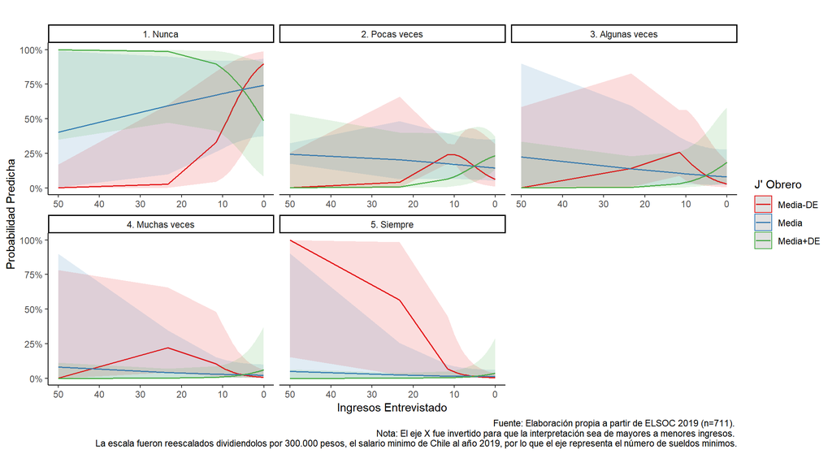